신록예찬's 블로그

# (노트) 히스토그램 이퀄라이저

Sep 14, 2022 • 신록예찬 • 3 min read

시각화2022

- 오늘 배울 내용?
- 이미지자료 다운로드
- 이미지자료의 이해
  - 비밀1: 이미지는 사실 숫자들의 집합이었음.
  - 비밀2: 칼라이미지는 red + green + blue 의 조합으로 표현가능 (다른방식도 가능)
- 히스토그램 이퀄라이저
- 히스토그램 이퀄라이저 (흑백버전)
- 잡담

## 오늘 배울 내용?

`-` 히스토그램의 활용: 정규분포인지 판단 <- 지난시간

`-` 히스토그램의 활용2: 이미지 보정! 히스토그램 이퀄라이저 <- 이게 이번시간

## 이미지자료 다운로드

```python
import cv2
import matplotlib.pyplot as plt
import pandas as pd
```

```python
import numpy as np
```

```python
!wget https://upload.wikimedia.org/wikipedia/commons/0/08/Unequalized_Hawkes_Bay_NZ.jpg
img = cv2.imread('Unequalized_Hawkes_Bay_NZ.jpg')
!rm Unequalized_Hawkes_Bay_NZ.jpg # 삭제
```

```
--2022-09-14 13:05:18--  https://upload.wikimedia.org/wikipedia/commons/0/08/Unequalized_Hawkes_Bay_NZ.jpg
Resolving upload.wikimedia.org (upload.wikimedia.org)... 103.102.166.240, 2001:df2:e500:ed1a::2:b
Connecting to upload.wikimedia.org (upload.wikimedia.org)|103.102.166.240|:443... connected.
HTTP request sent, awaiting response... 200 OK
Length: 110895 (108K) [image/jpeg]
Saving to: ‘Unequalized_Hawkes_Bay_NZ.jpg’

Unequalized_Hawkes_ 100%[===================>] 108.30K   499KB/s    in 0.2s

2022-09-14 13:05:18 (499 KB/s) - ‘Unequalized_Hawkes_Bay_NZ.jpg’ saved [110895/110895]
```

```python
img
```

```
array([[[127, 127, 127],
        [145, 145, 145],
        [149, 149, 149],
        ...,
        [168, 168, 168],
        [167, 167, 167],
        [166, 166, 166]],

       [[165, 165, 165],
        [152, 152, 152],
        [143, 143, 143],
        ...,
        [168, 168, 168],
        [169, 169, 169],
        [168, 168, 168]],

       [[171, 171, 171],
        [145, 145, 145],
        [140, 140, 140],
        ...,
        [156, 156, 156],
        [154, 154, 154],
        [151, 151, 151]],

       ...,

       [[147, 147, 147],
        [132, 132, 132],
        [134, 134, 134],
        ...,
        [146, 146, 146],
        [145, 145, 145],
        [144, 144, 144]],

       [[146, 146, 146],
        [130, 130, 130],
        [132, 132, 132],
        ...,
        [146, 146, 146],
        [145, 145, 145],
        [144, 144, 144]],

       [[145, 145, 145],
        [128, 128, 128],
        [129, 129, 129],
        ...,
        [146, 146, 146],
        [145, 145, 145],
        [144, 144, 144]]], dtype=uint8)
```

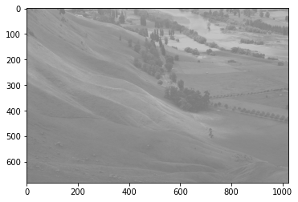

```python
plt.imshow(img)
```

## 이미지자료의 이해

### 비밀1: 이미지는 사실 숫자들의 집합이었음.

`-` 예시1

```python
_img1 = np.array([0,30,90,120,150,180,210,240,255]).reshape(3,3)
_img1
```

```
array([[  0,  30,  90],
       [120, 150, 180],
       [210, 240, 255]])
```

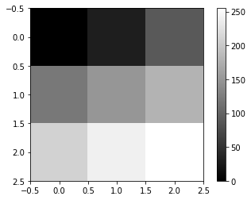

```python
plt.imshow(_img1,cmap='gray')
plt.colorbar()
```

`-` 예시2

```python
_img2 = np.array([0,20,40,60,80,100,120,140,160]).reshape(3,3)
_img2
```

```
array([[  0,  20,  40],
       [ 60,  80, 100],
       [120, 140, 160]])
```

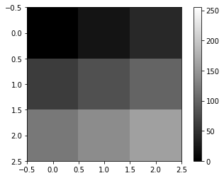

```python
plt.imshow(_img2,cmap='gray',vmin=0,vmax=255)
plt.colorbar()
```

`-` 예시3

```python
_img3 = np.concatenate([_img1, _img2],axis=1)
_img3
```

```
array([[  0,  30,  90,   0,  20,  40],
       [120, 150, 180,  60,  80, 100],
       [210, 240, 255, 120, 140, 160]])
```

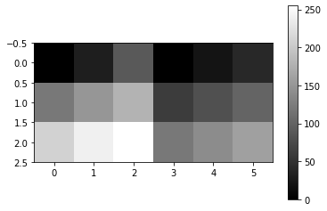

```python
plt.imshow(_img3,cmap='gray',vmin=0,vmax=255)
plt.colorbar()
```

### 비밀2: 칼라이미지는 red + green + blue 의 조합으로 표현가능 (다른방식도 가능)

`-` 예시1

```python
r = np.array([0]*25*3).reshape(5,5,3)
g = np.array([0]*25*3).reshape(5,5,3)
b = np.array([0]*25*3).reshape(5,5,3)
```

```python
r[:3,:3,0] = 255
g[:3,2:,1] = 255
b[2:,:,2] = 255
```

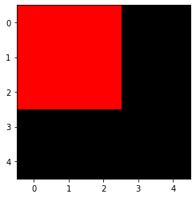

```python
plt.imshow(r)
```

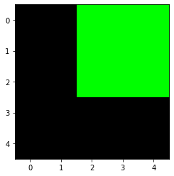

```python
plt.imshow(g)
```

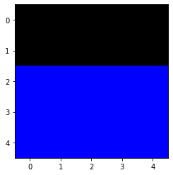

```python
plt.imshow(b)
```

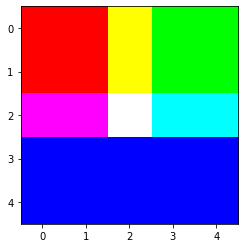

```python
plt.imshow(r+g+b)
```

`-` 예시2: RGB를 같은 비율로 섞으면 무채색이 된다.

```python
r = np.array([0]*25*3).reshape(5,5,3)
g = np.array([0]*25*3).reshape(5,5,3)
b = np.array([0]*25*3).reshape(5,5,3)
```

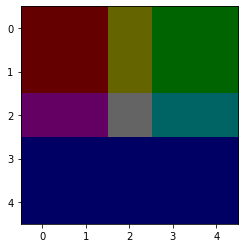

```python
r[:3,:3,0] = 100
g[:3,2:,1] = 100
b[2:,:,2] = 100
plt.imshow(r+g+b)
```

`-` 예시3

```python
img.shape
```

```
(683, 1024, 3)
```

```python
img_red = img*0
img_green = img*0
img_blue = img*0
```

```python
img_red[:,:,0] = img[:,:,0]
img_green[:,:,1] = img[:,:,1]
img_blue[:,:,2] = img[:,:,2]
```

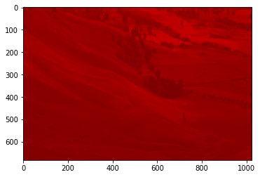

```python
plt.imshow(img_red)
```

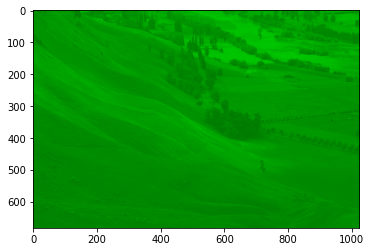

```python
plt.imshow(img_green)
```

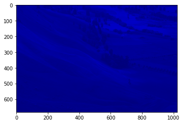

```python
plt.imshow(img_blue)
```

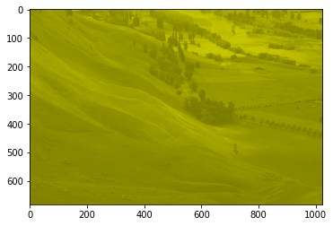

```python
plt.imshow(img_red+img_green)
```

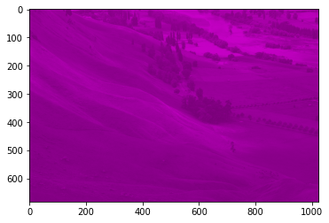

```python
plt.imshow(img_red+img_blue)
```

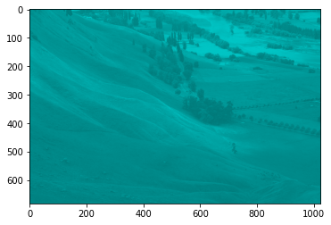

```python
plt.imshow(img_green+img_blue)
```

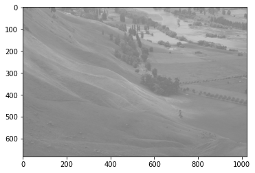

```python
plt.imshow(img_red+img_blue+img_green)
```

## 히스토그램 이퀄라이저

`-` img를 rgb로 분리하고 각 색깔들의 histogram을 그려보자.

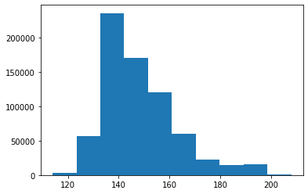

```python
plt.hist(img[:,:,0].reshape(-1))
```

- 히스토그램 그림1

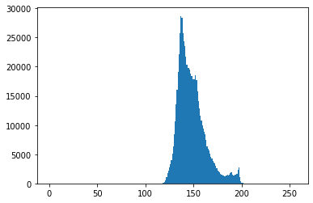

```python
_fig=plt.hist(img[:,:,0].reshape(-1),bins=255,range=[0,256]) ## 빨
```

- 히스토그램 그림2
- 히스토그램을 그려보니 전체적으로 120~200 사이에 값이 너무 몰려있음
- 원래 컴퓨터는 0~255까지의 색을 표현할 수 있음. 그런데 컴퓨터가 표현가능한 색보다 적은 조합만 사용함.
- 아이디어: 좀 더 다양한 색을 표현할 수 없을까? $\to$ 위의 히스토그램을 좀 더 평평하게 만들면 되는거아닌가?

`-` 분포의 모양은 대략적으로 유지하면서, 값을 퍼트린다면?

```python
img2_red = cv2.equalizeHist(img[...,0])
```

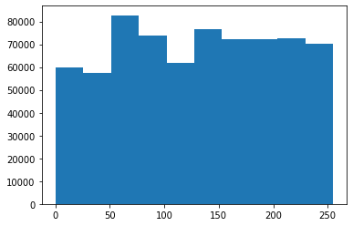

```python
plt.hist(img2_red.reshape(-1))
```

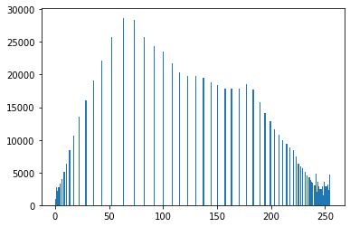

```python
_fig=plt.hist(img2_red.reshape(-1),bins=255,range=[0,255]) ## 빨?
```

`-` red말고 다른채널에도 이와 같이 한다면?

```python
img2= np.stack([img2_red,img2_red,img2_red],axis=-1)
```

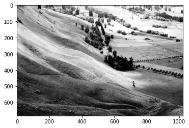

```python
plt.imshow(img2)
```

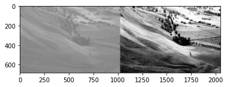

```python
plt.imshow(np.concatenate([img,img2],axis=1))
```

## 히스토그램 이퀄라이저 (흑백버전)

```python
!wget https://upload.wikimedia.org/wikipedia/commons/0/08/Unequalized_Hawkes_Bay_NZ.jpg
img_black = cv2.imread('Unequalized_Hawkes_Bay_NZ.jpg',0)
!rm Unequalized_Hawkes_Bay_NZ.jpg # 삭제
```

```
--2022-09-14 14:11:06--  https://upload.wikimedia.org/wikipedia/commons/0/08/Unequalized_Hawkes_Bay_NZ.jpg
Resolving upload.wikimedia.org (upload.wikimedia.org)... 103.102.166.240, 2001:df2:e500:ed1a::2:b
Connecting to upload.wikimedia.org (upload.wikimedia.org)|103.102.166.240|:443... connected.
HTTP request sent, awaiting response... 200 OK
Length: 110895 (108K) [image/jpeg]
Saving to: ‘Unequalized_Hawkes_Bay_NZ.jpg’

Unequalized_Hawkes_ 100%[===================>] 108.30K   500KB/s    in 0.2s

2022-09-14 14:11:07 (500 KB/s) - ‘Unequalized_Hawkes_Bay_NZ.jpg’ saved [110895/110895]
```

```python
img_black.shape ### 흑백이미지
```

```
(683, 1024)
```

```python
img_black2 = cv2.equalizeHist(img_black)
```

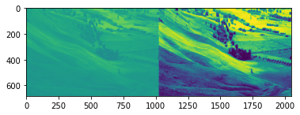

```python
plt.imshow(np.concatenate([img_black,img_black2],axis=1))
```

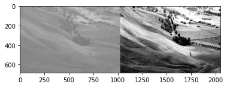

```python
plt.imshow(np.concatenate([img_black,img_black2],axis=1),cmap='gray')
```

## 잡담

`-` 명암비를 개선하는 알고리즘은 언뜻 생각하면 통계와 관련이 없어보임

`-` 그런데 이미지든 음성이든 결국 컴퓨터가 이해하기 위해서는 숫자로 바꿔야함

`-` 통계학은 숫자들을 다루는 학문임 (수학보다 더!)